# Modeling and prediction for movies

## Setup

### Load packages

```r
library(ggplot2)
library(dplyr)
library(statsr)
library(GGally)
```

### Load data

```r
 setwd("C:\\DataScinceTrack\\DUKE\\DUKE-STAT-COURSES\\Rgression_project")
load("movies.Rdata")
```

## Part 1: Data

- Rrandomly sampled movies released before 2016. -we cannot perform causation since it can only be inferred from a randomized experiment.(and no expermint here). - associations. cant be infered since observational studies are generally only used to show associations. - only correlations can be infered and since the sampling is random the results are generalisable to the bigger population * * *

## Part 2: Research question

Response variable: explantory variables :

does best_pic_nom ,best_pic_win best_actor_win,best_actress_win, best_dir_win, top200_box affected (have influence on) audience_score

## Part 3: Exploratory data analysis

```r
#Exploring Data
nrow(movies)
```

```
## [1] 651
```

```r
ncol(movies)
```

```
## [1] 32
```

```r
str(movies)
```

```
## Classes 'tbl_df', 'tbl' and 'data.frame':    651 obs. of  32 variables:
##  $ title           : chr  "Filly Brown" "The Dish" "Waiting for Guffman" "The Age of Innocence" ...
##  $ title_type      : Factor w/ 3 levels "Documentary",..: 2 2 2 2 2 1 2 2 1 2 ...
##  $ genre           : Factor w/ 11 levels "Action & Adventure",..: 6 6 4 6 7 5 6 6 5 6 ...
##  $ runtime         : num  80 101 84 139 90 78 142 93 88 119 ...
##  $ mpaa_rating     : Factor w/ 6 levels "G","NC-17","PG",..: 5 4 5 3 5 6 4 5 6 6 ...
##  $ studio          : Factor w/ 211 levels "20th Century Fox",..: 91 202 167 34 13 163 147 118 88 84 ...
##  $ thtr_rel_year   : num  2013 2001 1996 1993 2004 ...
##  $ thtr_rel_month  : num  4 3 8 10 9 1 1 11 9 3 ...
##  $ thtr_rel_day    : num  19 14 21 1 10 15 1 8 7 2 ...
##  $ dvd_rel_year    : num  2013 2001 2001 2001 2005 ...
##  $ dvd_rel_month   : num  7 8 8 11 4 4 2 3 1 8 ...
##  $ dvd_rel_day     : num  30 28 21 6 19 20 18 2 21 14 ...
##  $ imdb_rating     : num  5.5 7.3 7.6 7.2 5.1 7.8 7.2 5.5 7.5 6.6 ...
##  $ imdb_num_votes  : int  899 12285 22381 35096 2386 333 5016 2272 880 12496 ...
```

[output cut: 18 more lines]

```r
head(movies)
```

```
## # A tibble: 6 × 32
##                  title   title_type       genre runtime mpaa_rating
##                  <chr>       <fctr>      <fctr>   <dbl>      <fctr>
## 1          Filly Brown Feature Film       Drama      80           R
## 2             The Dish Feature Film       Drama     101       PG-13
## 3  Waiting for Guffman Feature Film      Comedy      84           R
## 4 The Age of Innocence Feature Film       Drama     139          PG
## 5          Malevolence Feature Film      Horror      90           R
## 6          Old Partner  Documentary Documentary      78     Unrated
## # ... with 27 more variables: studio <fctr>, thtr_rel_year <dbl>,
## #   thtr_rel_month <dbl>, thtr_rel_day <dbl>, dvd_rel_year <dbl>,
## #   dvd_rel_month <dbl>, dvd_rel_day <dbl>, imdb_rating <dbl>,
## #   imdb_num_votes <int>, critics_rating <fctr>, critics_score <dbl>,
## #   audience_rating <fctr>, audience_score <dbl>, best_pic_nom <fctr>,
## #   best_pic_win <fctr>, best_actor_win <fctr>, best_actress_win <fctr>,
## #   best_dir_win <fctr>, top200_box <fctr>, director <chr>, actor1 <chr>,
## #   actor2 <chr>, actor3 <chr>, actor4 <chr>, actor5 <chr>,
## #   imdb_url <chr>, rt_url <chr>
```

```r
# head(movies[, c(1:15, 10)])
#
# head(movies[, c(15:25, 10)])
#
# head(movies[, c(25:32, 10)])


#unique(movies$actor1)

# unique(movies$audience_rating)
# unique(movies$critics_rating)
# unique(movies$mpaa_rating)
# unique(movies$studio)
# unique(movies$title_type)

summary(movies$audience_score)
```

```
##    Min. 1st Qu.  Median    Mean 3rd Qu.    Max.
##   11.00   46.00   65.00   62.36   80.00   97.00
```

```r
summary(movies$critics_score)
```

```
##    Min. 1st Qu.  Median    Mean 3rd Qu.    Max.
##    1.00   33.00   61.00   57.69   83.00  100.00
```

```r
# group movies by type
movies_type_group  <- group_by(movies, title_type ) %>%
        summarize(movies = mean(audience_score))

movies_type_group
```

```
## # A tibble: 3 × 2
##     title_type   movies
##         <fctr>    <dbl>
## 1  Documentary 83.25455
## 2 Feature Film 60.46531
## 3     TV Movie 56.80000
```

```r
movies_arranged  <-  arrange(movies, desc( audience_score))


# top 10 score movies
head(movies_arranged[ ,1], 10)
```

```
## # A tibble: 10 × 1
##                        title
##                        <chr>
## 1     The Godfather, Part II
## 2                   Promises
## 3        The Five Heartbeats
## 4  In the Name of the Father
## 5                     Aliens
## 6           The Color Purple
## 7                    Memento
## 8          Good Will Hunting
## 9          Teenage Paparazzo
## 10                Annie Hall
```

```r
#last 10
tail(movies_arranged[ ,1], 10)
```

```
## # A tibble: 10 × 1
##                   title
##                   <chr>
## 1  Welcome to Mooseport
## 2                Doogal
## 3         Viva Knievel!
## 4         The Mod Squad
## 5         Teen Wolf Too
## 6        The Babysitter
## 7                  Bats
## 8        Town & Country
## 9                Meteor
## 10    Battlefield Earth
```

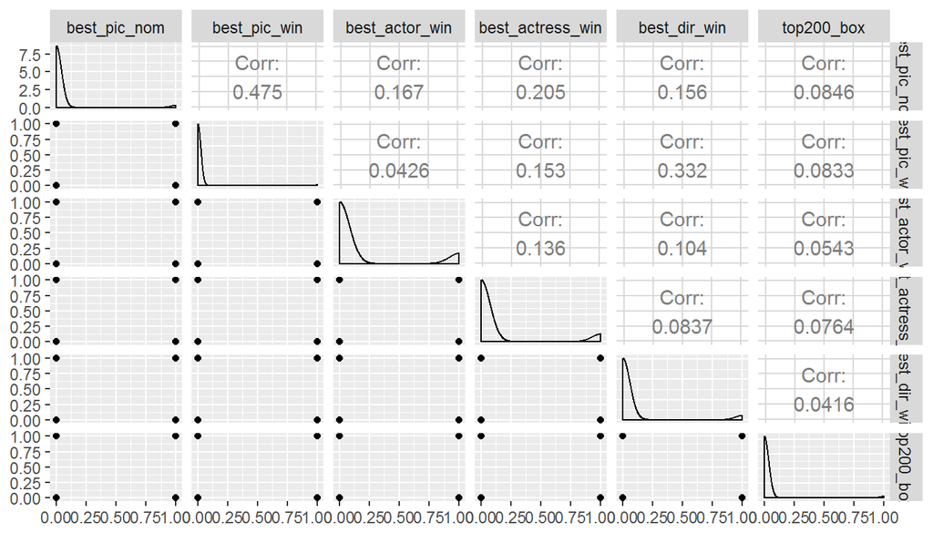

```r
#EXPLORE DATA USING PLOTS
# replace character values from col 19 to 24 with numeric values yes=1 and no =0



#from summary we  can see that highest and min score for audiances and critics


movies[19:24]<-ifelse(movies[19:24] =='yes', 1,0)
ggpairs(movies, columns = 19:24)
```

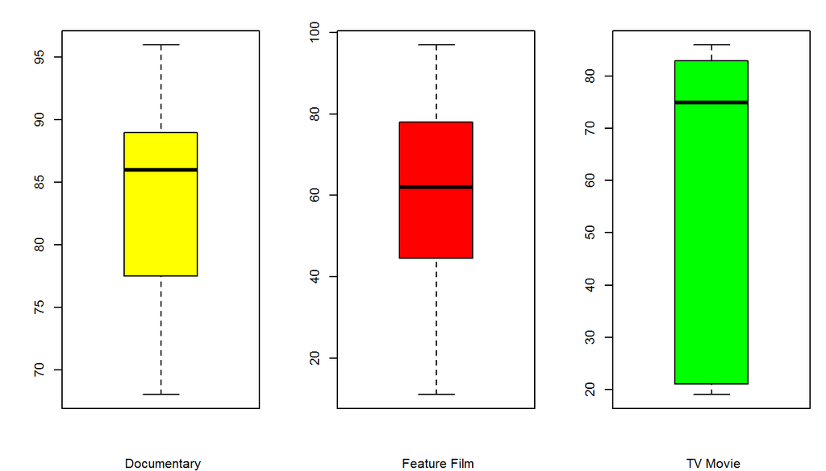

```r
par(mfrow = c(1, 3), mar = c(4, 4, 2, 1))
boxplot( movies[movies$title_type=='Documentary', ]$audience_score , xlab= " Documentary" ,col= "yellow")
boxplot( movies[movies$title_type=='Feature Film', ]$audience_score , xlab= " Feature Film" ,col= "red" )
boxplot( movies[movies$title_type=='TV Movie', ]$audience_score , xlab= " TV Movie" ,col= "green" )
```

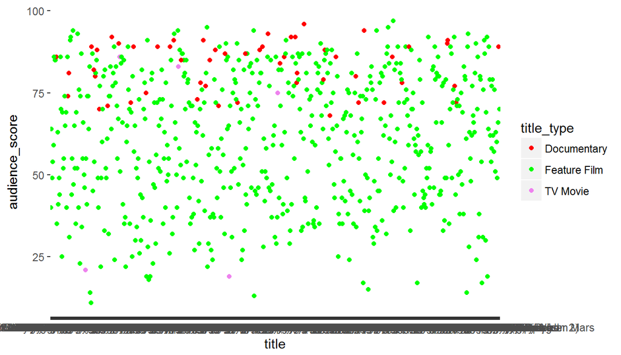

```r
#audiance score scatter plot
plot(movies$audience_score)

Palette1 <- c('red','green','violet','black')
ggplot( data=movies, aes(y=audience_score,x= title )) +
        geom_point(aes(colour =title_type))+
  scale_colour_manual(values=Palette1 )
```

[output not shown]

## Part 4: Modeling

Model the relation between audience_score as respnose variable and columns 19:24 best_pic_nom ,best_pic_win best_actor_win,best_actress_win, best_dir_win, top200_box

```r
movies[1:5,19:24]
```

```
## # A tibble: 5 × 6
##   best_pic_nom best_pic_win best_actor_win best_actress_win best_dir_win
##          <dbl>        <dbl>          <dbl>            <dbl>        <dbl>
## 1            0            0              0                0            0
## 2            0            0              0                0            0
## 3            0            0              0                0            0
## 4            0            0              1                0            1
## 5            0            0              0                0            0
## # ... with 1 more variables: top200_box <dbl>
```

[output not shown]

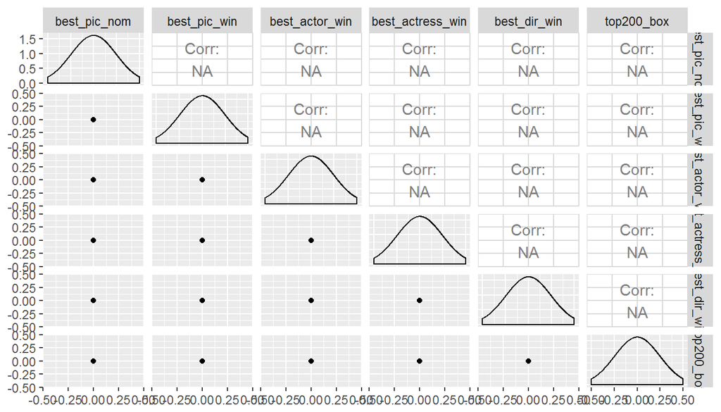

```r
movies[19:24]<-ifelse(movies[19:24] =='yes', 1,0)
ggpairs(movies, columns = 19:24)
```

```r
#  parametersnot corolated strongly
# backword modeling method 0 full mpdel


m_full <- lm(audience_score ~ best_pic_nom + best_pic_win + best_actor_win + best_actress_win + best_dir_win + top200_box , data = movies)
summary(m_full)
```

```
##
## Call:
## lm(formula = audience_score ~ best_pic_nom + best_pic_win + best_actor_win +
##     best_actress_win + best_dir_win + top200_box, data = movies)
##
## Residuals:
##     Min      1Q  Median      3Q     Max
## -51.363 -16.363   2.637  17.637  34.637
##
## Coefficients: (6 not defined because of singularities)
##                  Estimate Std. Error t value Pr(>|t|)
## (Intercept)       62.3625     0.7926   78.68   <2e-16 ***
## best_pic_nom           NA         NA      NA       NA
## best_pic_win           NA         NA      NA       NA
## best_actor_win         NA         NA      NA       NA
## best_actress_win       NA         NA      NA       NA
## best_dir_win           NA         NA      NA       NA
## top200_box             NA         NA      NA       NA
## ---
## Signif. codes:  0 '***' 0.001 '**' 0.01 '*' 0.05 '.' 0.1 ' ' 1
##
## Residual standard error: 20.22 on 650 degrees of freedom
```

```r
summary(m_full)$adj.r.squared
```

```
## [1] 0
```

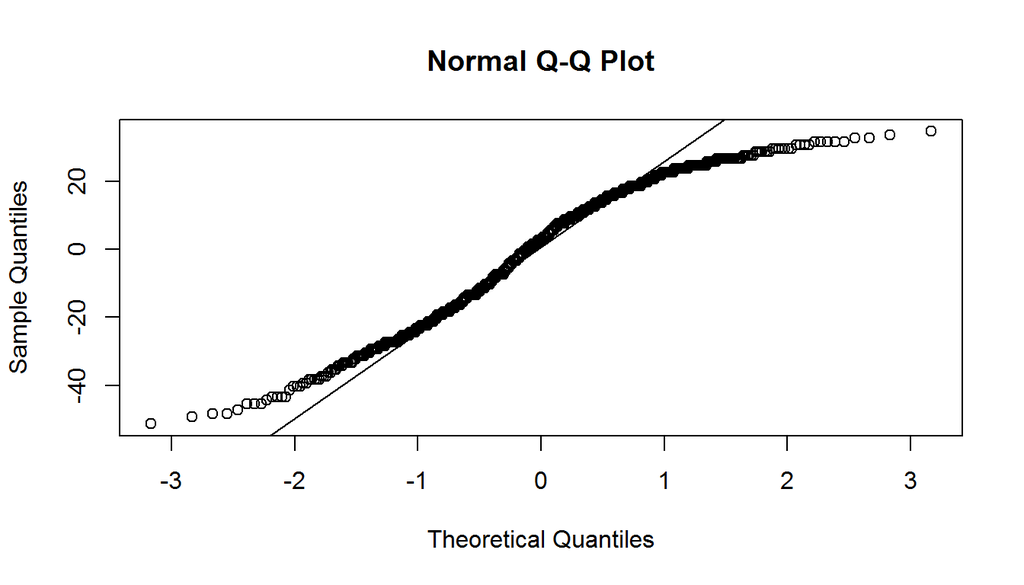

```r
qqnorm(m_full$residuals)
qqline(m_full$residuals)
```

```r
ml <- lm(audience_score ~ best_pic_nom +   best_actor_win + best_actress_win + best_dir_win + top200_box , data = movies)
summary(ml)
```

```
##
## Call:
## lm(formula = audience_score ~ best_pic_nom + best_actor_win +
##     best_actress_win + best_dir_win + top200_box, data = movies)
##
## Residuals:
##     Min      1Q  Median      3Q     Max
## -51.363 -16.363   2.637  17.637  34.637
##
## Coefficients: (5 not defined because of singularities)
##                  Estimate Std. Error t value Pr(>|t|)
## (Intercept)       62.3625     0.7926   78.68   <2e-16 ***
## best_pic_nom           NA         NA      NA       NA
## best_actor_win         NA         NA      NA       NA
## best_actress_win       NA         NA      NA       NA
## best_dir_win           NA         NA      NA       NA
## top200_box             NA         NA      NA       NA
## ---
## Signif. codes:  0 '***' 0.001 '**' 0.01 '*' 0.05 '.' 0.1 ' ' 1
##
## Residual standard error: 20.22 on 650 degrees of freedom
```

```r
summary(ml)$adj.r.squared
```

```
## [1] 0
```